# Менеджер пакетов RPM

НКАбд-06-23

Улитина М.М.

Российский университет дружбы народов, Москва, Россия

20 мая 2024

# Информация

## Докладчик

- Улитина Мария Максимовна
- студентка группы НКАбд-06-23
- Российский университет дружбы народов

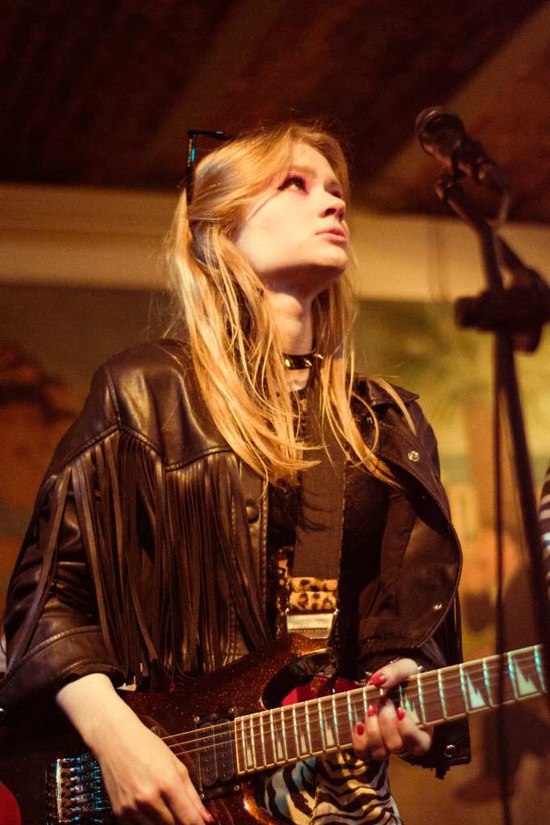

# Введение

## Введение

Система управления пакетами («менеджер пакетов» или «пакетный менеджер») — набор программного обеспечения, позволяющего управлять процессом установки, удаления, настройки и обновления различных компонентов программного обеспечения.

# Основная часть

## Общая характеристика и основные понятия

RPM (RPM Package Manager) популярный формат пакетов программного обеспечения, а также программа для создания и управления этими пакетами.

Существует два типа RPM пакетов:

1. source RPM (SRPM) - исходный;
2. binary RPM - бинарный.

## Применение RPM

Пакетный менеджер RPM применяется для:

1. создание пакетов, пригодных для дистрибуции из файлов программ.
2. установки, обновления и удаления упакованных программ.
3. запроса детальной информации о пакетах программного обеспечения: установлены ли они или нет.
4. подтверждения целостности установленного программного обеспечения и результатов установки программного обеспечения.

## Преимущества RPM

1. Возможность установки, удаления, обновления, а также подтверждения программных пакетов совместно с Yum.
2. Использование базы данных установленных пакетов для запроса информации о пакетах и подтверждение пакетов.
3. Использование метаданных для описания пакетов, их инструкций по установке и других параметров пакетов.
4. Возможность собрать исходные файлы программного обеспечения, патчи, инструкции установки в исходные и бинарные файлы.
5. Добавление пакетов в репозитории Yum.
6. Цифровая подпись пакетов с использованием ключей.

## Основы создания пакета в RPM - преамбула

1. Name - имя;
2. Version - версия;
3. Release - релиз;
4. Summary - краткое описание пакета;
5. License - лицензия.
6. URL - ссылка на дополнительную информацию о программе;
7. BuildArch - архитектура компьютера для запуска программы;
8. Requires - системные требования.

## Основы создания пакета в RPM - основная часть

1. %description - полное описание программного обеспечения, содержащегося в пакете;
2. %prep - команда/команды, для подготовки ПО к сборке;
3. %build - команда/команды для самой сборки ПО;
4. %install - команда/команды, используемые для копирования необходимых в дальнейшем файлов, полученных при сборке;
5. %check - команда/команды для тестирования ПО;
6. %files - список файлов, которые будут установлены конечному пользователю программы;
7. %changelog - журнал изменений пакета.

## Основы создания пакета в RPM

$ rpmdev-setuptree $ rpmbuild -ba filename.spec

## Проверка качества пакета

rpmlint совершает следующие действия:

1. Улучшает поддерживаемость RPM;
2. Осуществляет проверку на ошибки и взаимосвязи компонентов пакета.

# Выводы

## Выводы

RPM - полезный пакетный менеджер, содержащий множество функций и параметров. В дополнение к своей функциональности он прост и понятен в использовании.

## Список литературы

1. https://rpm-packaging-guide.github.io/#what-is-an-rpm
2. https://ru.wikipedia.org/wiki/RPM
3. https://ru.wikipedia.org/wiki/%D0%9F%D0%B0%D0%BA%D0%B5%D1%82_%D0%BF%D1%80%D0%B8%D0%BA%D0%BB%D0%B0%D0%B4%D0%BD%D1%8B%D1%85_%D0%BF%D1%80%D0%BE%D0%B3%D1%80%D0%B0%D0%BC%D0%BC